# Regression and model validation

We consider a cross-sectional dataset from 2014 containing statistics students’ answers to questions regarding teaching and learning. The data contains 166 observations for 7 variables: gender (Male or Female), age, attitude (related to learning statistics, scale 1-5), deep (average of answers related to deep learning, scale 1-5), stra (average of answers related to strategic learning, scale 1-5), surf (average of answers related to surface learning), and points (exam points). Besides the variable gender (which is of the type character), all the variables are numeric and treated as continuous. The data is loaded below where also its structure and dimensions are pre-examined, confirming our above description of the data types and the numbers of observations and variables.

```r
learning2014 <- read.csv("data/learning2014.csv")
head(learning2014, n=5) # The first 5 rows of the data frame
```

```
##   gender age attitude     deep  stra     surf points
## 1      F  53      3.7 3.583333 3.375 2.583333     25
## 2      M  55      3.1 2.916667 2.750 3.166667     12
## 3      F  49      2.5 3.500000 3.625 2.250000     24
## 4      M  53      3.5 3.500000 3.125 2.250000     10
## 5      M  49      3.7 3.666667 3.625 2.833333     22
```

```r
str(learning2014) # Variables and their types
```

```
## 'data.frame':    166 obs. of  7 variables:
##  $ gender  : chr  "F" "M" "F" "M" ...
##  $ age     : int  53 55 49 53 49 38 50 37 37 42 ...
##  $ attitude: num  3.7 3.1 2.5 3.5 3.7 3.8 3.5 2.9 3.8 2.1 ...
##  $ deep    : num  3.58 2.92 3.5 3.5 3.67 ...
##  $ stra    : num  3.38 2.75 3.62 3.12 3.62 ...
##  $ surf    : num  2.58 3.17 2.25 2.25 2.83 ...
##  $ points  : int  25 12 24 10 22 21 21 31 24 26 ...
```

After pre-examining the data structure, it is often useful to study the data graphically as it potentially reveals important relations between the observations. A graphical summary of the data is presented below:

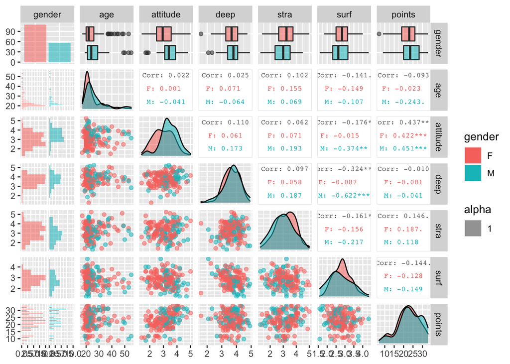

```r
# Load the required packages
library(ggplot2)
library(GGally, quietly=TRUE)

# Create the summary plot
p <- ggpairs(learning2014, mapping=aes(col=gender, alpha=1), legend=1,
             upper=list(continuous=wrap("cor", size=2.5)),
             lower=list(combo=wrap(ggally_facethist, binwidth=0.5)))
```

The above summary graph matrix contains several components in which the respondents are separated by their gender. In the diagonal, we first have a bar plot expressing the distribution of males and females: apparently there are almost twice as many females as there are males. The rest of the diagonal shows density diagrams expressing an estimate of continuous density of the observations based on the sample. For the variables age, deep, and points, the distributions are rather similar for both genders. It appears, however, that males got on average more points on attitude, while females scored more in strategic learning and surface learning. Moreover, most of the distributions seem non-Gaussian. Particularly the age distribution is very skewed due to the larger number of young than old respondents. These distributions are presented in an alternative way as histograms in the first column of the graph matrix and also as boxplots in the first row of the graph matrix.

Excluding the first column and row, the lower triangular of the graph matrix contains 2D scatter plots between all the numeric variables and the upper triangular the sample correlations. Linear relations (i.e. correlations) between individual variables are mostly quite week, expect that there is relatively high correlation between attitude and points for both females and males. There is also large negative correlation between surface learning and attitude as well as between surface learning and deep learning for males only. The negative correlation between age and points for males seems also notable as there is practically no correlation for females. This could be, however, because of the relatively small number of old males as each of them then has relatively large influence of the sample correlation. This can be checked by calculating the sample correlation between age and points for males of age less than 40:

```r
cor(subset(learning2014, gender == "M" & age < 40, select=c("age", "points")))[1, 2]
```

```
## [1] 0.1032825
```

which is slightly positive and thus confirms our suspicions. The rest of the linear relations between the pairs of variables are mostly relatively similar to males and females, although there are some smaller differences.

To examine the distributions and their normality when the observations are not separated by gender, we plot histograms of the numeric variables and on top of them draw a graph of the density of the normal distribution estimated for the sample.

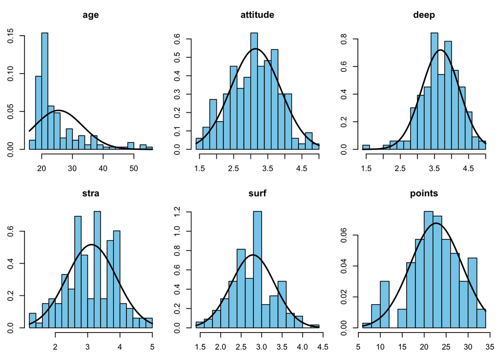

```r
par(mfrow=c(2, 3), mar=c(2.6, 2.6, 3, 1)) # Set graphical parameters
for(i1 in 2:ncol(learning2014)) { # Go through the numerical variables
  dat <- learning2014[,i1]
  tmp <- hist(dat, col="skyblue", breaks=15, freq=FALSE,
              main=colnames(learning2014[i1]))
  x <- seq(from=min(tmp$breaks), to=max(tmp$breaks), length.out=200)
  lines(x=x, y=dnorm(x, mean=mean(dat), sd=sd(dat)), lwd=2)
}
```

As expected, the overall age distribution is skewed. However, for attitude and deep learning the overall distribution somewhat resembles the normal distribution. Strategic learning, surface learning, and exam points are not either very far from Gaussianity when one accounts for the discrete nature of histograms in that the shape of the distribution is to some extend affected by the number of breaks.

We are interested in modelling linear relations of the exam points to the other variables. A suitable method is therefore a linear regression model of the form $y_i = \beta_0 + \beta_1x_{i1} + \cdots + \beta_Kx_{iK} + \varepsilon_i$ where $y_i$ is the $i$th observation, $x_{ik}$ is the corresponding $k$th explanatory variable, $\varepsilon_i$ is an error term, and $\beta_0,...,\beta_K$ are regression coefficients. The model is estimated by finding values for $\beta_0,...,\beta_K$, say $b_0,...,b_K$, such that the sum of squared residuals is minimized. The residuals are defined as $y_i - \hat{y}_i$ where $\hat{y}_i \equiv b_0 + b_1x_{i1} + \cdots + b_Kx_{iK}$ is the fitted value.

For constructing a linear model to explain variations in the exam points, our strategy is to find explanatory variables that have strong linear relation to the points variable. Based on the above summary graph matrix, attitude is the first choice. We also include strategic learning and surface learning as for both of them the sample correlation to points is larger than for the other continuous variables. These three variables also carry the advantage that the correlations are similar for males and females, implying that we most likely don’t need separate regression lines (or hyperplanes) for different genders. Particularly we are leaving out age from the regression as the correlation to points is quite different for males and females, while the negative correlation of males is mainly attributed to the relatively poorly scoring small group of old male respondents.

Below, we estimate the model and examine its summary statistics:

```r
m1 <- lm(points ~ attitude + stra + surf, data=learning2014)
summary(m1)
```

```
##
## Call:
## lm(formula = points ~ attitude + stra + surf, data = learning2014)
##
## Residuals:
##      Min       1Q   Median       3Q      Max
## -17.1550  -3.4346   0.5156   3.6401  10.8952
##
## Coefficients:
##             Estimate Std. Error t value Pr(>|t|)
## (Intercept)  11.0171     3.6837   2.991  0.00322 **
## attitude      3.3952     0.5741   5.913 1.93e-08 ***
## stra          0.8531     0.5416   1.575  0.11716
## surf         -0.5861     0.8014  -0.731  0.46563
## ---
## Signif. codes:  0 '***' 0.001 '**' 0.01 '*' 0.05 '.' 0.1 ' ' 1
##
## Residual standard error: 5.296 on 162 degrees of freedom
## Multiple R-squared:  0.2074, Adjusted R-squared:  0.1927
## F-statistic: 14.13 on 3 and 162 DF,  p-value: 3.156e-08
```

The estimate for the intercept parameter is approximately $11$, meaning that without any points from attutitude, strategic learning, or surface learning, the model predicts $11$ points from the exam. The estimate for the slope parameter of attitude is approximately $3.40$. The model therefore predicts that, ceteris paribus, scoring one extra point from attitude increases exam points by $3.40$. Similarly an extra point in strategic learning predicts $0.85$ points more in the exam and surface learning $0.59$ points less.

The $t$-tests, for which the $p$-values are given above in the right-most column under the headline “coefficients”, test the null hypothesis that the true regression coefficient is zero. The tests are valid in finite (i.e. “small”) samples if conditionally on the regressors, the errors are independently and jointly normally distributed with zero mean and common variance. Asymptotically (i.e. in “large” samples), the tests are valid under more relaxed conditions, however. The $p$-value expresses the probability of observing a sample that is as or more deviant from null than the observed data if the null is true. Small $p$-values can thereby be considered as evidence against the null hypothesis, at least as long as the assumptions required for the validity of the test are satisfied. That is, the intercept parameter and the slope parameter for attitude are most likely not zero ($p$-values are less than $0.01$), whereas for the slope parameters of stra and surf we cannot reject the hypothesis that they are zero ($p$-values are larger than $0.05$).

The $F$-test, for which the results are presented in the bottom row of the summary print, tests the null hypothesis that all the non-intercept regression coefficients are zero (in general, $F$-test can be used to test other hypotheses as well, however). The $p$-value is very small, so all the slope coefficients are most likely not zero. Based on the above discussion on the $t$-tests, one of the non-zero slope coefficients seems to be the one of attitude.

Because the coefficient for surface learning obtained the highest $p$-value from the $t$-test and surface learning does not have a statistically significant relation exam points when also relations to attitude and strategic learning are accounted for, we reduce the variable from the model, re-estimate, and check the summary statistics again:

```r
m2 <- update(m1, ~ .-surf)
summary(m2)
```

```
##
## Call:
## lm(formula = points ~ attitude + stra, data = learning2014)
##
## Residuals:
##      Min       1Q   Median       3Q      Max
## -17.6436  -3.3113   0.5575   3.7928  10.9295
##
## Coefficients:
##             Estimate Std. Error t value Pr(>|t|)
## (Intercept)   8.9729     2.3959   3.745  0.00025 ***
## attitude      3.4658     0.5652   6.132 6.31e-09 ***
## stra          0.9137     0.5345   1.709  0.08927 .
## ---
## Signif. codes:  0 '***' 0.001 '**' 0.01 '*' 0.05 '.' 0.1 ' ' 1
##
## Residual standard error: 5.289 on 163 degrees of freedom
## Multiple R-squared:  0.2048, Adjusted R-squared:  0.1951
## F-statistic: 20.99 on 2 and 163 DF,  p-value: 7.734e-09
```

As is shown in the above summary print, when surface learning was removed from the explanatory variables, strategic learning became statistically more significant. The $p$-value of the $t$-test is still more than $0.05$ but as it is less than $0.1$, strategic learning has some statistical significance in this model and we don’t therefore remove it. Compared to the previous model with also surface learning as a regressor, an extra point in attitude or strategic learning now predicts approximately $0.07$ or $0.06$ exam points more. That is, ceteris paribus, one more point in attitude now predicts $3.47$ exam points more and strategic learning $0.91$ points. These two variables became (statistically) more significant after removing surface learning, which is negatively correlated with points, from the model because they are both negatively correlated with it, and therefore some of their relation to exam points was attributed to the surface learning in the larger model. Another way to look at it is that some of surface learning’s relation to exam points is now attributed to attitude and strategic learning.

The intercept parameter estimate got smaller and it is now approximately $9$. The model therefore predicts $9$ points in the exam for a student that has zero points in attitude and strategic learning. The multiple R-squared statistic tells what portion of the variation in the exam points can be explained by variation in the explanatory variables, attitude and strategic learning. The value is $0.20$ so our model is able to explain one fifth of the variation in the exam points.

Next, we examine residual plots in order to evaluate how well the model assumptions are satisfied.

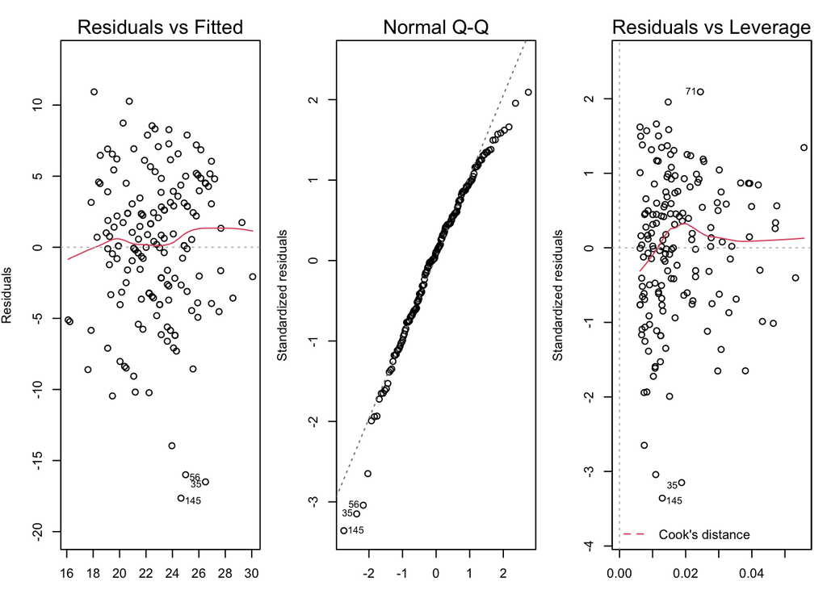

```r
par(mfrow=c(1, 3), mar=c(2.6, 3.9, 2.6, 1))
plot(m2, which=c(1, 2, 5))
```

First, examine the figure of the left which shows the scatter plot of the residuals against the fitted values. Residuals are the empirical counterparts of the error terms, defined as the differences between the observations and fitted values. A residual in the zero line implies that the corresponding observation is equal to the fitted value and deviation from the zero line gives the observation’s deviation from the fitted value. The red curvy line is a smoother that helps in discovering patterns in the residuals. If the relationship between the variables is linear, the smoother should be an approximately straight horizontal line passing through origo, which it is, at least to some extend. The assumption of constant error variance (conditionally on the regressors) implies that there should not be any apparent changes in the variation of the residuals. There is slightly smaller variance at the end and the four largest negative residuals appear as larger variance just before the reduction in the variance, so the assumption of constant variance is not perfectly satisfied. Overall, the defects don’t seem very serious, however.

The figure in the middle is normal QQ plot in which the sample quantiles of standardized residuals (standardized by dividing by their estimated standard errors) are plotted against the theoretical quantiles of standard normal distribution. If the errors are normally distributed, the points in the plot should all fall approximately on the straight dashed line (if the errors are independently and identically normally distributed, the standardized residuals actually follow a Student’s $t$ distribution. When sample size is large, the shape of the $t$-distribution does not deviate much from standard normal, however). This is not exactly the case above: it seems that there are too much too small residuals and not enough large residuals. That is, the sample distribution of the residuals is skewed to the left and it has too fat lower tail but not fat enough upper tail. Nonetheless, the sample distribution seems normal enough to have some faith in the statistical tests discussed above.

Finally, on the right we have the figure of standardized residuals plotted against their leverage. The leverage on the $x$-axis measures how influential the observations corresponding to the residuals are in the ordinary least squares estimation: observations with larger influence affect the coefficient estimates more. Thus, if there are large residuals with large influence, they may significantly distort the regression line (or hyperplane - in our case a regression plane as there are two explanatory variables) from where it would be without the outlier(s). The red curve in the figure is a smoother that helps to detect patterns in the residuals. It should be an approximately straight horizontal line passing through origo to implicate that there are no distorting observations. Is can be seen, there is a small group of large negative residuals deviating from others but fortunately they are not very influential. The smoother seems also straight enough, so we may conclude that there does not seem to be very problematic influential outliers. In summary, the overall fit of the model and validity of the assumption of linear relationships and jointly normal independent errors with common variance seems reasonable but possibly not exactly satisfied.